# Peak Bloom Prediction Analysis

Arinjita Bhattacharyya

2/28/2022

## Instructions

```r
library(tidyverse)
set.seed(1)
library(tseries)
library(forecast)
library(Metrics)
library(ggplot2)
library(readr)
library(WaveletArima)
library(caret)
library(nnfor)
library(tsDyn)
library(fracdiff)
library(bsts)
library(forecastHybrid)
library(e1071)
library(tseriesChaos)
library(pracma)
library(Kendall)
library(nonlinearTseries)
library(GeneCycle)
library(fpp2)
library(ggfortify)
library(MTS)
library(WaveletArima)
library(smooth)
```

## Loading the data

The data for each of the three main sites is provided as simple text file in CSV format. Each file contains the dates of the peak bloom of the cherry trees at the respective site, alongside the geographical location of the site.

- *location* a human-readable location identifier (`string`).
- *lat* (approximate) latitude of the cherry trees (`double`).
- *long* (approximate) longitude of the cherry trees (`double`).
- *alt* (approximate) altitude of the cherry trees (`double`).
- *year* year of the observation (`integer`).
- *bloom_date* date of peak bloom of the cherry trees (ISO 8601 date `string`). The “peak bloom date” may be defined differently for different sites
- *bloom_doy* days since January 1st of the year until peak bloom (`integer`). January 1st corresponds to `1`.

In R, the data files can be read with `read.csv()` and concatenated with the `bind_rows()` function:

```r
cherry <- read.csv("data/washingtondc.csv") %>%
  bind_rows(read.csv("data/liestal.csv")) %>%
  bind_rows(read.csv("data/kyoto.csv"))
```

```r
cherry %>%
  group_by(location) %>%
  slice_tail(n = 3)
```

| location | lat | long | alt | year | bloom_date | bloom_doy |
| --- | --- | --- | --- | --- | --- | --- |
| kyoto | 35.01198 | 135.676114 | 44 | 2019 | 2019-04-05 | 95 |
| kyoto | 35.01198 | 135.676114 | 44 | 2020 | 2020-04-01 | 92 |
| kyoto | 35.01198 | 135.676114 | 44 | 2021 | 2021-03-26 | 85 |
| liestal | 47.48140 | 7.730519 | 350 | 2019 | 2019-03-27 | 86 |
| liestal | 47.48140 | 7.730519 | 350 | 2020 | 2020-03-17 | 77 |
| liestal | 47.48140 | 7.730519 | 350 | 2021 | 2021-03-28 | 87 |
| washingtondc | 38.88535 | -77.038628 | 0 | 2019 | 2019-04-01 | 91 |
| washingtondc | 38.88535 | -77.038628 | 0 | 2020 | 2020-03-20 | 80 |
| washingtondc | 38.88535 | -77.038628 | 0 | 2021 | 2021-03-28 | 87 |

## Visualizing the time series

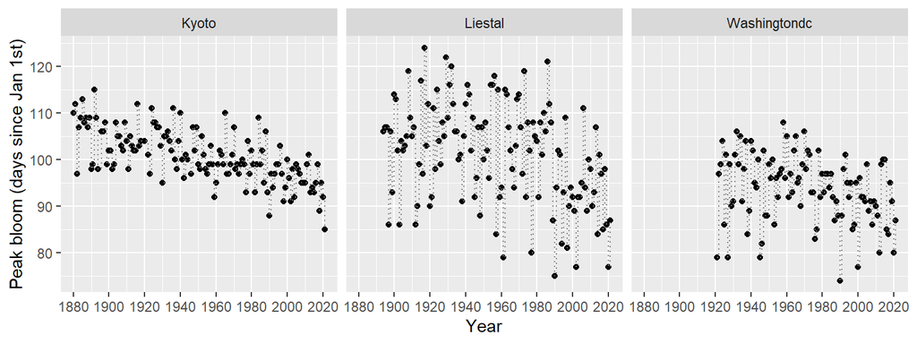

Time series of peak bloom of cherry trees since 1880 at three different sites.

```r
cherry %>%
  filter(year >= 1880) %>%
  ggplot(aes(x = year, y = bloom_doy)) +
  geom_point() +
  geom_step(linetype = 'dotted', color = 'gray50') +
  scale_x_continuous(breaks = seq(1880, 2020, by = 20)) +
  facet_grid(cols = vars(str_to_title(location))) +
  labs(x = "Year", y = "Peak bloom (days since Jan 1st)")
```

## Predicting the peak bloom

#Using univariate and hybrid Time series forecasting methods

```r
tsdata<-subset(cherry,year >= 1880)
loc<-table(tsdata$location)
tsky<-subset(tsdata,location=="kyoto")$bloom_doy
tsli<-subset(tsdata,location=="liestal")$bloom_doy
tsdc<-subset(tsdata,location=="washingtondc")$bloom_doy
length(tsky)
```

```
## [1] 138
```

```r
length(tsli)
```

```
## [1] 128
```

```r
length(tsdc)
```

```
## [1] 101
```

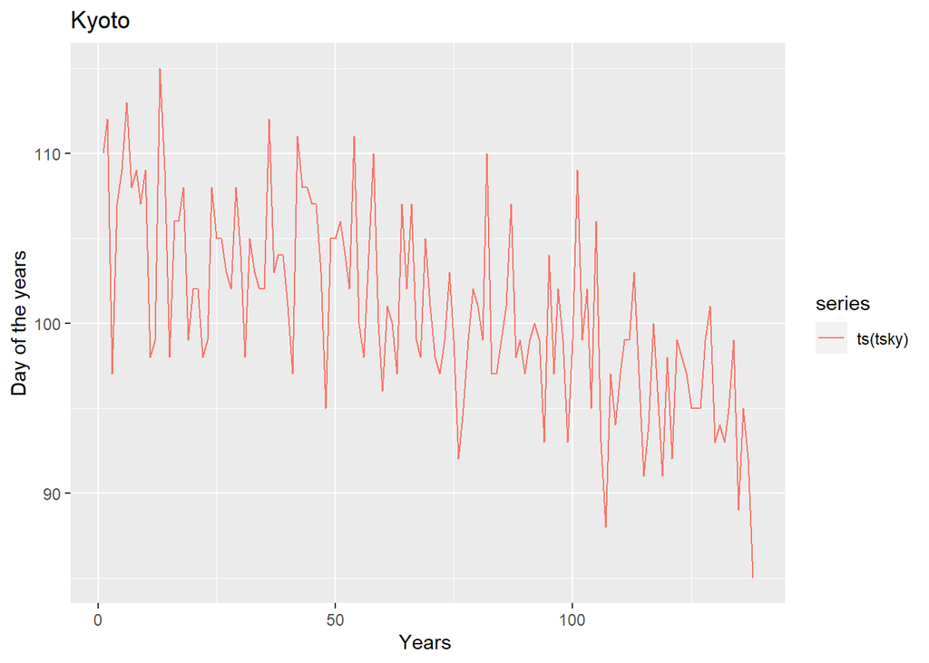

```r
tskytrain<-tsky[1:128]
tskytest<-tsky[129:138]
tslitrain<-tsli[1:118]
tslitest<-tsli[119:128]
tsdctrain<-tsdc[1:91]
tsdctest<-tsdc[92:101]
######################## PLOTS

autoplot(ts(tsky))+ ggtitle('Kyoto')+ylab('Day of the years')+xlab('Years ')+autolayer(ts(tsky))
```

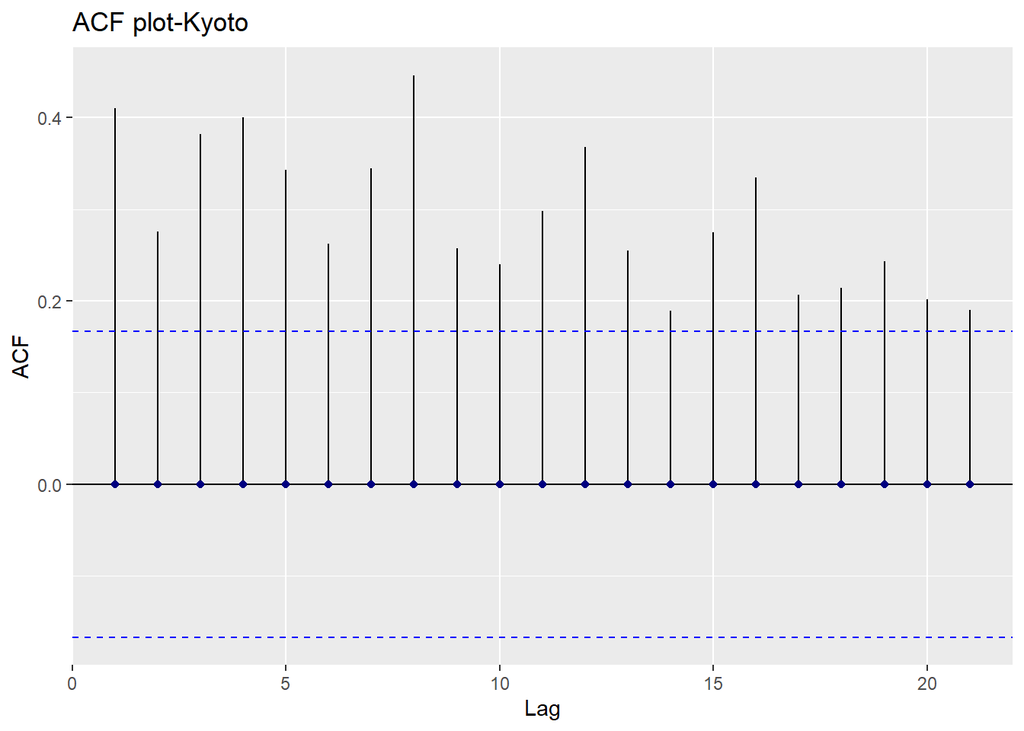

```r
diffset = diff(tsky, differences = ndiffs(tsky))
ggAcf(tsky)+geom_point(color = 'navy blue') +ggtitle("ACF plot-Kyoto")
```

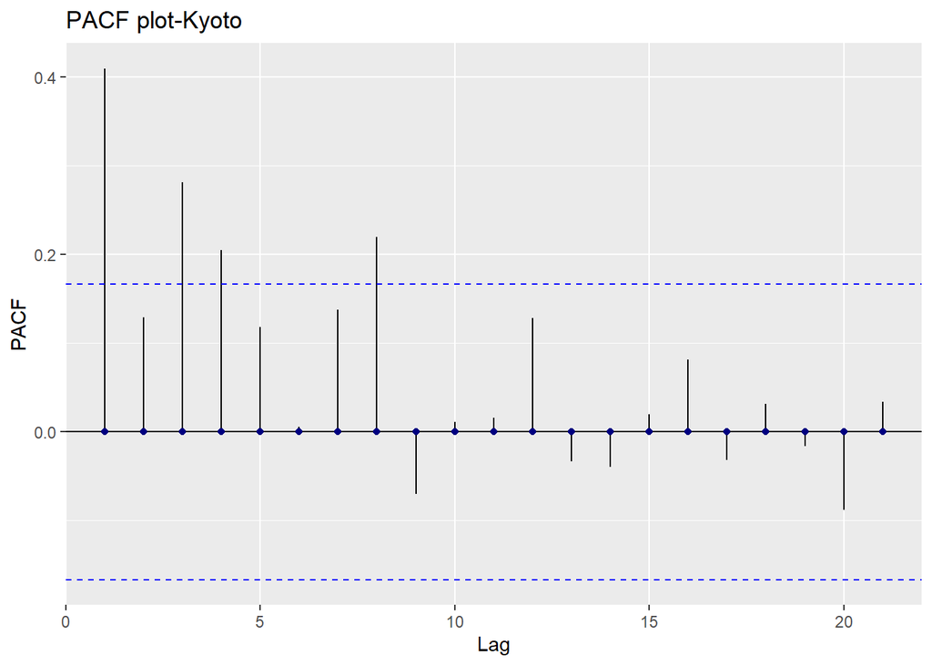

```r
ggPacf(tsky) + geom_point(color = 'navy blue') + ggtitle("PACF plot-Kyoto")
```

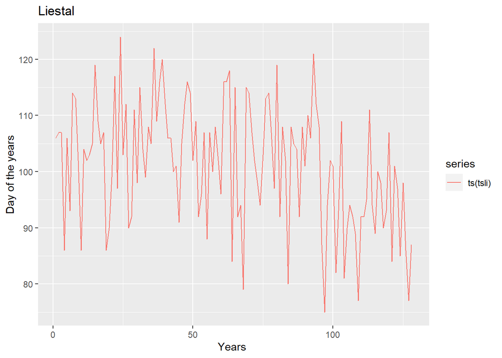

```r
autoplot(ts(tsli))+ ggtitle('Liestal')+ylab('Day of the years')+xlab('Years ')+autolayer(ts(tsli))
```

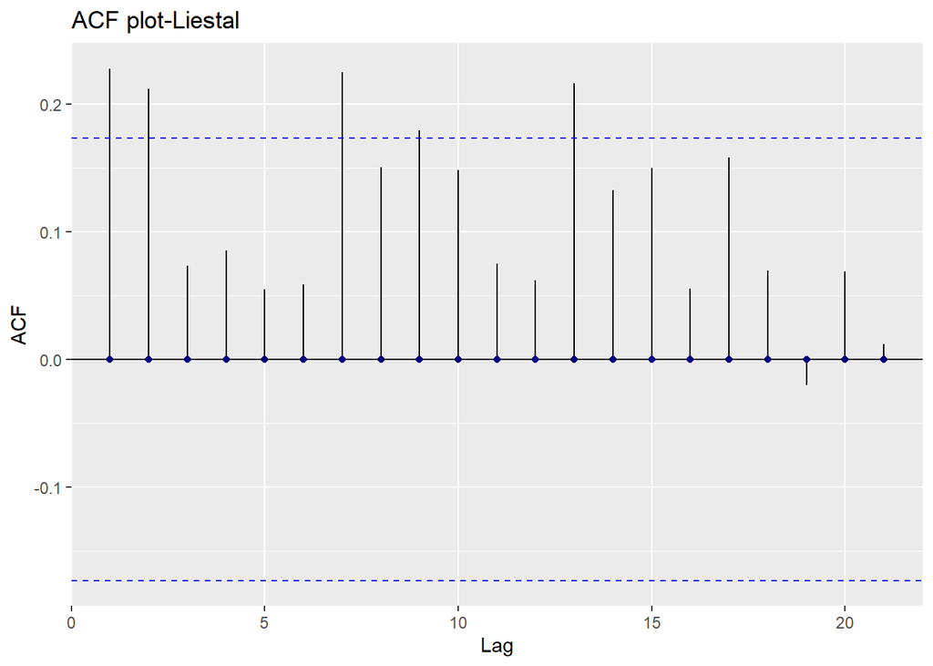

```r
diffset = diff(tsli, differences = ndiffs(tsli))
ggAcf(tsli)+geom_point(color = 'navy blue') +ggtitle("ACF plot-Liestal")
```

[figure not shown]

```r
ggPacf(tsky) + geom_point(color = 'navy blue') + ggtitle("PACF plot-Liestal")
```

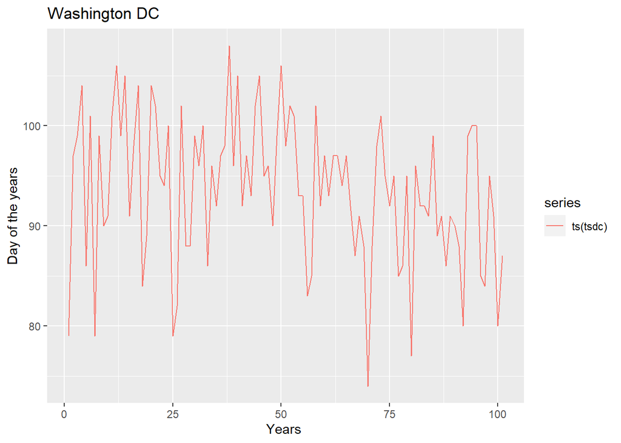

```r
autoplot(ts(tsdc))+ ggtitle('Washington DC')+ylab('Day of the years')+xlab('Years ')+autolayer(ts(tsdc))
```

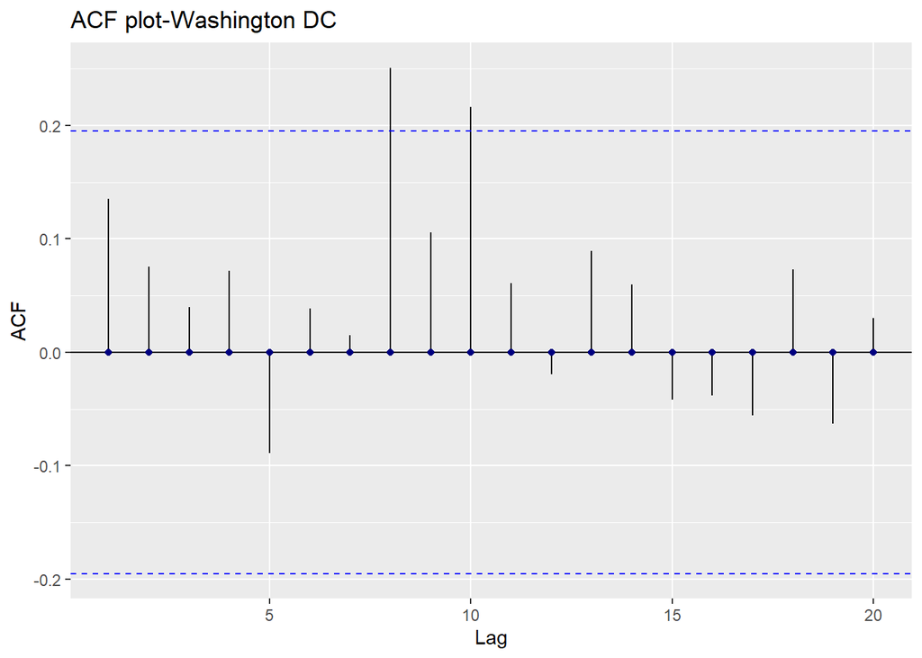

```r
diffset = diff(tsdc, differences = ndiffs(tsdc))
ggAcf(tsdc)+geom_point(color = 'navy blue') +ggtitle("ACF plot-Washington DC")
```

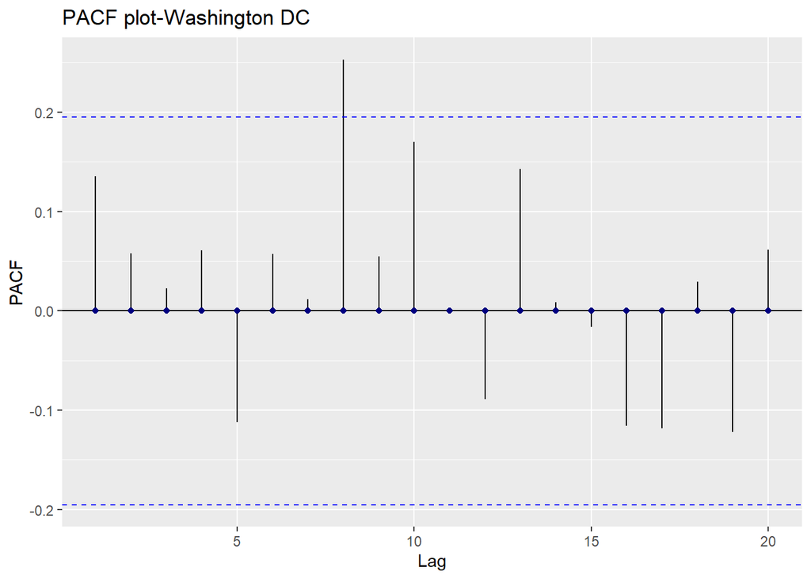

```r
ggPacf(tsdc) + geom_point(color = 'navy blue') + ggtitle("PACF plot-Washington DC")
```

```r
################# Statistical Tests ############################

fracdiff(tsky)
```

```
##
## Call:
##   fracdiff(x = tsky)
##
## Coefficients:
##         d
## 0.3110405
## sigma[eps] = 4.728651
## a list with components:
##  [1] "log.likelihood"  "n"               "msg"             "d"
##  [5] "ar"              "ma"              "covariance.dpq"  "fnormMin"
##  [9] "sigma"           "stderror.dpq"    "correlation.dpq" "h"
## [13] "d.tol"           "M"               "hessian.dpq"     "length.w"
## [17] "residuals"       "fitted"          "call"
```

```r
fracdiff(tsli)
```

```
##
## Call:
##   fracdiff(x = tsli)
##
## Coefficients:
##         d
## 0.2038378
## sigma[eps] = 10.35241
## a list with components:
##  [1] "log.likelihood"  "n"               "msg"             "d"
##  [5] "ar"              "ma"              "covariance.dpq"  "fnormMin"
##  [9] "sigma"           "stderror.dpq"    "correlation.dpq" "h"
## [13] "d.tol"           "M"               "hessian.dpq"     "length.w"
## [17] "residuals"       "fitted"          "call"
```

```r
fracdiff(tsdc)
```

```
##
## Call:
##   fracdiff(x = tsdc)
##
## Coefficients:
##         d
## 0.1243893
## sigma[eps] = 7.144523
## a list with components:
##  [1] "log.likelihood"  "n"               "msg"             "d"
##  [5] "ar"              "ma"              "covariance.dpq"  "fnormMin"
##  [9] "sigma"           "stderror.dpq"    "correlation.dpq" "h"
## [13] "d.tol"           "M"               "hessian.dpq"     "length.w"
## [17] "residuals"       "fitted"          "call"
```

```r
hurstexp(tsky)
```

```
## Simple R/S Hurst estimation:         0.7477372
## Corrected R over S Hurst exponent:   0.9709562
## Empirical Hurst exponent:            0.6067089
## Corrected empirical Hurst exponent:  0.6265882
## Theoretical Hurst exponent:          0.5260215
```

```r
hurstexp(tsli)
```

```
## Simple R/S Hurst estimation:         0.6698678
## Corrected R over S Hurst exponent:   0.9157333
## Empirical Hurst exponent:            0.6062277
## Corrected empirical Hurst exponent:  0.6274127
## Theoretical Hurst exponent:          0.525374
```

```r
hurstexp(tsdc)
```

```
## Simple R/S Hurst estimation:         0.6305416
## Corrected R over S Hurst exponent:   0.7942551
## Empirical Hurst exponent:            0.4881644
## Corrected empirical Hurst exponent:  0.5276308
## Theoretical Hurst exponent:          0.5229461
```

```r
Box.test(tsky, lag = 1, type = c("Box-Pierce"))
```

```
##
##  Box-Pierce test
##
## data:  tsky
## X-squared = 23.198, df = 1, p-value = 1.461e-06
```

```r
Box.test(tsli, lag = 1, type = c("Box-Pierce"))
```

```
##
##  Box-Pierce test
##
## data:  tsli
## X-squared = 6.6366, df = 1, p-value = 0.009991
```

```r
Box.test(tsdc, lag = 1, type = c("Box-Pierce"))
```

```
##
##  Box-Pierce test
##
## data:  tsdc
## X-squared = 1.849, df = 1, p-value = 0.1739
```

```r
skewness(tsky)
```

```
## [1] 0.08629771
```

```r
skewness(tsli)
```

```
## [1] -0.2344549
```

```r
skewness(tsdc)
```

```
## [1] -0.389511
```

```r
kurtosis(tsky)
```

```
## [1] -0.306408
```

```r
kurtosis(tsli)
```

```
## [1] -0.6295121
```

```r
kurtosis(tsdc)
```

```
## [1] -0.3800148
```

```r
############ARIMA
#########Train test data

f1ky = auto.arima(as.ts(tskytrain))
fof1ky =  as.numeric(predict(f1ky, 10)$pred)
er1ky<-round(mean(abs(fof1ky- tskytest)),2)

f1li= auto.arima(as.ts(tslitrain))
fof1li =  as.numeric(predict(f1li, 10)$pred)
er1li<-round(mean(abs(fof1li- tslitest)),2)


f1dc = auto.arima(as.ts(tsdctrain))
fof1dc =  as.numeric(predict(f1dc, 10)$pred)
er1dc<-round(mean(abs(fof1dc- tsdctest)),2)



##########full data ARIMA

fit_arimaky = auto.arima(ts(tsky),trace = TRUE)
```

```
##
##  ARIMA(2,1,2) with drift         : Inf
##  ARIMA(0,1,0) with drift         : 880.0596
##  ARIMA(1,1,0) with drift         : 858.8543
##  ARIMA(0,1,1) with drift         : Inf
##  ARIMA(0,1,0)                    : 878.1299
##  ARIMA(2,1,0) with drift         : 835.7038
##  ARIMA(3,1,0) with drift         : 823.7308
##  ARIMA(4,1,0) with drift         : 821.6567
##  ARIMA(5,1,0) with drift         : 823.0524
##  ARIMA(4,1,1) with drift         : Inf
##  ARIMA(3,1,1) with drift         : Inf
##  ARIMA(5,1,1) with drift         : Inf
##  ARIMA(4,1,0)                    : 820.3779
##  ARIMA(3,1,0)                    : 822.2791
##  ARIMA(5,1,0)                    : 821.8683
##  ARIMA(4,1,1)                    : 810.2514
##  ARIMA(3,1,1)                    : 808.0936
##  ARIMA(2,1,1)                    : 806.0049
##  ARIMA(1,1,1)                    : 809.0527
##  ARIMA(2,1,0)                    : 833.9957
##  ARIMA(2,1,2)                    : 808.0991
##  ARIMA(1,1,0)                    : 857.0321
##  ARIMA(1,1,2)                    : 809.8465
##  ARIMA(3,1,2)                    : 810.2569
##  ARIMA(2,1,1) with drift         : Inf
##
##  Best model: ARIMA(2,1,1)
```

```r
forecast_arimaky= predict(fit_arimaky,10)
fit_arimali = auto.arima(ts(tsli),trace = TRUE)
```

```
##
##  ARIMA(2,1,2) with drift         : 963.6708
##  ARIMA(0,1,0) with drift         : 1025.91
##  ARIMA(1,1,0) with drift         : 991.3897
##  ARIMA(0,1,1) with drift         : 959.2056
##  ARIMA(0,1,0)                    : 1023.861
##  ARIMA(1,1,1) with drift         : 960.5295
##  ARIMA(0,1,2) with drift         : 960.6623
##  ARIMA(1,1,2) with drift         : 962.4435
##  ARIMA(0,1,1)                    : 958.8733
##  ARIMA(1,1,1)                    : 960.3541
##  ARIMA(0,1,2)                    : 960.4456
##  ARIMA(1,1,0)                    : 989.3583
##  ARIMA(1,1,2)                    : 962.3175
##
##  Best model: ARIMA(0,1,1)
```

```r
forecast_arimali= predict(fit_arimali,10)

fit_arimadc = auto.arima(ts(tsdc),trace = TRUE)
```

```
##
##  ARIMA(2,1,2) with drift         : Inf
##  ARIMA(0,1,0) with drift         : 737.1044
##  ARIMA(1,1,0) with drift         : 715.2185
##  ARIMA(0,1,1) with drift         : Inf
##  ARIMA(0,1,0)                    : 735.0287
##  ARIMA(2,1,0) with drift         : 709.0571
##  ARIMA(3,1,0) with drift         : 705.1108
##  ARIMA(4,1,0) with drift         : 707.0651
##  ARIMA(3,1,1) with drift         : Inf
##  ARIMA(2,1,1) with drift         : Inf
##  ARIMA(4,1,1) with drift         : Inf
##  ARIMA(3,1,0)                    : 702.9089
##  ARIMA(2,1,0)                    : 706.8894
##  ARIMA(4,1,0)                    : 704.8185
##  ARIMA(3,1,1)                    : 690.4418
##  ARIMA(2,1,1)                    : 688.3495
##  ARIMA(1,1,1)                    : 686.1785
##  ARIMA(0,1,1)                    : 684.3708
##  ARIMA(0,1,2)                    : 686.1815
##  ARIMA(1,1,0)                    : 713.0922
##  ARIMA(1,1,2)                    : 688.35
##
##  Best model: ARIMA(0,1,1)
```

```r
forecast_arimadc= predict(fit_arimadc,10)

##############Theta model
#########Train test data

f2ky = thetaf(as.ts(tskytrain))
fof2ky =  as.numeric(predict(f2ky, 10)$mean)
er2ky<-round(mean(abs(fof2ky- tskytest)),2)

f2li= thetaf(as.ts(tslitrain))
fof2li =   as.numeric(predict(f2li, 10)$mean)
er2li<-round(mean(abs(fof2li- tslitest)),2)


f2dc = thetaf(as.ts(tsdctrain))
fof2dc =   as.numeric(predict(f2dc, 10)$mean)
er2dc<-round(mean(abs(fof2dc- tsdctest)),2)

############full data Theta

fit_thetaky=thetaf(as.ts(tsky), h=10)
forecast_thetaky= predict(fit_thetaky,10)$mean
fit_thetali=thetaf(as.ts(tsli), h=10)
forecast_thetali= predict(fit_thetali,10)$mean

fit_thetadc=thetaf(as.ts(tsdc), h=10)
forecast_thetadc= predict(fit_thetadc,10)$mean
##############Wavelet WARIMA
#########Train test data

f3ky = WaveletFittingarma(ts(tskytrain), Waveletlevels = floor(log(length(tskytrain))),boundary = "periodic", FastFlag = TRUE, MaxARParam = 10, MaxMAParam = 10, NForecast = 10)
fof3ky= as.numeric(f3ky$Finalforecast, h=10)
er3ky<-round(mean(abs(fof3ky- tskytest)),2)

f3li = WaveletFittingarma(ts(tslitrain), Waveletlevels = floor(log(length(tslitrain))),boundary = "periodic", FastFlag = TRUE, MaxARParam = 10, MaxMAParam = 10, NForecast = 10)
fof3li= as.numeric(f3li$Finalforecast, h=10)
er3li<-round(mean(abs(fof3li- tslitest)),2)

f3dc = WaveletFittingarma(ts(tsdctrain), Waveletlevels = floor(log(length(tsdctrain))),boundary = "periodic", FastFlag = TRUE, MaxARParam = 10, MaxMAParam = 10, NForecast = 10)
fof3dc= as.numeric(f3dc$Finalforecast, h=10)
er3dc<-round(mean(abs(fof3dc- tsdctest)),2)
###########full data WARIMA

fit_warimaky = WaveletFittingarma(ts(tsky), Waveletlevels = floor(log(length(tsky))),boundary = "periodic", FastFlag = TRUE, MaxARParam = 10, MaxMAParam = 10, NForecast = 10)
forecast_warimaky = as.data.frame(fit_warimaky$Finalforecast, h=10)

fit_warimali = WaveletFittingarma(ts(tsli), Waveletlevels = floor(log(length(tsli))),boundary = "periodic", FastFlag = TRUE, MaxARParam = 10, MaxMAParam = 10, NForecast = 10)

forecast_warimali = as.data.frame(fit_warimali$Finalforecast, h=10)
fit_warimadc = WaveletFittingarma(ts(tsdc), Waveletlevels = floor(log(length(tsdc))),boundary = "periodic", FastFlag = TRUE, MaxARParam = 10, MaxMAParam = 10, NForecast = 10)
forecast_warimadc = as.data.frame(fit_warimadc$Finalforecast, h=10)
################ ETS model###########################
#########Train test data

f4ky = ets(as.ts(tskytrain))
fof4ky =  as.numeric(predict(f4ky, 10)$mean)
er4ky<-round(mean(abs(fof4ky- tskytest)),2)

f4li= ets(as.ts(tslitrain))
fof4li =  as.numeric(predict(f4li, 10)$mean)
er4li<-round(mean(abs(fof4li- tslitest)),2)


f4dc = ets(as.ts(tsdctrain))
fof4dc =  as.numeric(predict(f4dc, 10)$mean)
er4dc<-round(mean(abs(fof4dc- tsdctest)),2)

############full data
fit_etsky = ets(as.ts(tsky))
forecast_etsky = forecast::forecast(fit_etsky, h = 10)
fit_etsli = ets(as.ts(tsli))
forecast_etsli = forecast::forecast(fit_etsli, h = 10)
fit_etsdc = ets(as.ts(tsdc))
forecast_etsdc = forecast::forecast(fit_etsdc, h = 10)
##################TBATS#######################

#########Train test data

f5ky = tbats(as.ts(tskytrain))
fof5ky =  as.numeric(predict(f5ky, 10)$mean)
er5ky<-round(mean(abs(fof5ky- tskytest)),2)

f5li= tbats(as.ts(tslitrain))
fof5li =  as.numeric(predict(f5li, 10)$mean)
er5li<-round(mean(abs(fof5li- tslitest)),2)


f5dc = tbats(as.ts(tsdctrain))
fof5dc =  as.numeric(predict(f5dc, 10)$mean)
er5dc<-round(mean(abs(fof5dc- tsdctest)),2)

############full data TBATS
fit_tbatsky = tbats(as.ts(tsky))
forecast_tbatsky=forecast::forecast(fit_tbatsky, h=10)
fit_tbatsli = tbats(as.ts(tsli))
forecast_tbatsli=forecast::forecast(fit_tbatsli, h=10)
fit_tbatsdc = tbats(as.ts(tsdc))
forecast_tbatsdc=forecast::forecast(fit_tbatsdc, h=10)

######################### Hybrid Models ########################Hybrid ARIMA-ARNN
#########Train test data
#f1ky = auto.arima(as.ts(tskytrain))
f6ky = nnetar(f1ky$residuals, repeats = 500, lambda="auto")
fof6ky1 =  forecast::forecast(f6ky, h = 10)
fof6ky =  predict(f1ky, 10)$pred+ fof6ky1$mean
er6ky<-round(mean(abs(fof6ky- tskytest)),2)

f6li = nnetar(f1li$residuals, repeats = 500, lambda="auto")
fof6li1 =  forecast::forecast(f6li, h = 10)
fof6li =  predict(f1li, 10)$pred+ fof6li1$mean
er6li<-round(mean(abs(fof6li- tslitest)),2)


f6dc = nnetar(f1dc$residuals, repeats = 500, lambda="auto")
fof6dc1 =  forecast::forecast(f6dc, h = 10)
fof6dc =  predict(f1dc, 10)$pred+ fof6dc1$mean
er6dc<-round(mean(abs(fof6dc- tsdctest)),2)

############full data
### Hybrid ARIMA-ARNN

fit_res_ARNNky = nnetar(fit_arimaky$residuals, repeats = 500, lambda="auto")
pred_res_ARNNky = forecast::forecast(fit_res_ARNNky, h = 10)
pred_arima_arnnky =  predict(fit_arimaky, 10)$pred+ pred_res_ARNNky$mean

fit_res_ARNNli = nnetar(fit_arimali$residuals, repeats = 500, lambda="auto")
pred_res_ARNNli = forecast::forecast(fit_res_ARNNli, h = 10)
pred_arima_arnnli = predict(fit_arimali, 10)$pred+
pred_res_ARNNli$mean
fit_res_ARNNdc = nnetar(fit_arimadc$residuals, repeats = 500, lambda="auto")
pred_res_ARNNdc = forecast::forecast(fit_res_ARNNdc, h = 10)
pred_arima_arnndc = predict(fit_arimadc, 10)$pred+
  pred_res_ARNNdc$mean
### #############Hybrid ARIMA-WARIMA
f7ky = WaveletFittingarma(f1ky$residuals, Waveletlevels = floor(log(length(tskytrain))), boundary = 'periodic', FastFlag = TRUE, MaxARParam = 5, MaxMAParam = 5, NForecast = 10)
fof7ky = predict(f1ky, 10)$pred + f7ky$Finalforecast
er7ky<-round(mean(abs(fof7ky- tskytest)),2)

f7li = WaveletFittingarma(f1li$residuals, Waveletlevels = floor(log(length(tslitrain))), boundary = 'periodic', FastFlag = TRUE, MaxARParam = 5, MaxMAParam = 5, NForecast = 10)
fof7li = predict(f1li, 10)$pred + f7li$Finalforecast
er7li<-round(mean(abs(fof7li- tslitest)),2)

f7dc = WaveletFittingarma(f1dc$residuals, Waveletlevels = floor(log(length(tsdctrain))), boundary = 'periodic', FastFlag = TRUE, MaxARParam = 5, MaxMAParam = 5, NForecast = 10)
fof7dc = predict(f1dc, 10)$pred + f7dc$Finalforecast
er7dc<-round(mean(abs(fof7dc- tsdctest)),2)

###########full data
fit_res_wbfky = WaveletFittingarma(fit_arimaky$residuals, Waveletlevels = floor(log(length(tsky))), boundary = 'periodic', FastFlag = TRUE, MaxARParam = 5, MaxMAParam = 5, NForecast = 10)
pred_arima_wbfky = predict(fit_arimaky, 10)$pred + fit_res_wbfky$Finalforecast

fit_res_wbfdc = WaveletFittingarma(fit_arimadc$residuals, Waveletlevels = floor(log(length(tsdc))), boundary = 'periodic', FastFlag = TRUE, MaxARParam = 5, MaxMAParam = 5, NForecast = 10)
pred_arima_wbfdc =predict(fit_arimadc, 10)$pred + fit_res_wbfdc$Finalforecast

fit_res_wbfli = WaveletFittingarma(fit_arimali$residuals, Waveletlevels = floor(log(length(tsli))), boundary = 'periodic', FastFlag = TRUE, MaxARParam = 5, MaxMAParam = 5, NForecast = 10)
pred_arima_wbfli = predict(fit_arimali, 10)$pred + fit_res_wbfli$Finalforecast
####################Hybrid Theta ARNN
##########Train Test data
f8ky<-thetaf(as.ts(tskytrain), h=10)
f8resky<-nnetar(f8ky$residuals, repeats = 500)
pred8ky = forecast::forecast(f8resky, h = 10)
fof8ky = predict(f8ky, 10)$mean + pred8ky$mean
er8ky<-round(mean(abs(fof8ky- tskytest)),2)

f8li<-thetaf(as.ts(tslitrain), h=10)
f8resli<-nnetar(f8li$residuals, repeats = 500)
pred8li = forecast::forecast(f8resli, h = 10)
fof8li= predict(f8li, 10)$mean + pred8li$mean
er8li<-round(mean(abs(fof8li- tslitest)),2)

f8dc<-thetaf(as.ts(tsdctrain), h=10)
f8resdc<-nnetar(f8dc$residuals, repeats = 500)
pred8dc = forecast::forecast(f8resdc, h = 10)
fof8dc= predict(f8dc, 10)$mean + pred8dc$mean
er8dc<-round(mean(abs(fof8dc- tsdctest)),2)
############Full data
fit_thetaky=thetaf(as.ts(tsky), h=10)
fit_res_TARNNky = nnetar(fit_thetaky$residuals, repeats = 500)
pred_res_TARNNky = forecast::forecast(fit_res_TARNNky, h = 10)
pred_theta_arnnky = predict(fit_thetaky, 10)$mean + pred_res_TARNNky$mean

fit_thetali=thetaf(as.ts(tsli), h=10)
fit_res_TARNNli = nnetar(fit_thetali$residuals, repeats = 500)
pred_res_TARNNli = forecast::forecast(fit_res_TARNNli, h = 10)
pred_theta_arnnli = predict(fit_thetali, 10)$mean + pred_res_TARNNli$mean
fit_thetadc=thetaf(as.ts(tsdc), h=10)
fit_res_TARNNdc = nnetar(fit_thetadc$residuals, repeats = 500)
pred_res_TARNNdc = forecast::forecast(fit_res_TARNNdc, h = 10)
pred_theta_arnndc = predict(fit_thetadc, 10)$mean + pred_res_TARNNdc$mean

################### SETAR ###########################
############train test
f9ky<-setar(as.ts(tskytrain), m = 4)
fof9ky<-predict(f9ky, n.ahead = 10)
er9ky<-round(mean(abs(fof9ky- tskytest)),2)

f9li<-setar(as.ts(tslitrain), m = 4)
fof9li<-predict(f9li, n.ahead = 10)
er9li<-round(mean(abs(fof9li- tslitest)),2)

f9dc<-setar(as.ts(tsdctrain), m = 4)
fof9dc<-predict(f9dc, n.ahead = 10)
er9dc<-round(mean(abs(fof9dc- tsdctest)),2)
############Full data
fit_SETARky = setar(as.ts(tsky), m = 4)
forecast_SETARky = predict(fit_SETARky, n.ahead = 10)
fit_SETARli = setar(as.ts(tsli), m = 4)
forecast_SETARli = predict(fit_SETARli, n.ahead = 10)
fit_SETARdc = setar(as.ts(tsdc), m = 4)
forecast_SETARdc = predict(fit_SETARdc, n.ahead = 10)
################### MLP/ANN ###################################
############train test
f10ky<-mlp(as.ts(tskytrain), hd = 5, reps = 1)
fof10ky<-as.numeric(forecast::forecast(f10ky, h=10)$mean)
er10ky<-round(mean(abs(fof10ky- tskytest)),2)

f10li<-mlp(as.ts(tslitrain), hd = 5, reps = 1)
fof10li<-as.numeric(forecast::forecast(f10li, h=10)$mean)
er10li<-round(mean(abs(fof10li- tslitest)),2)

f10dc<-mlp(as.ts(tsdctrain), hd = 5, reps = 1)
fof10dc<-as.numeric(forecast::forecast(f10dc, h=10)$mean)
er10dc<-round(mean(abs(fof10dc- tsdctest)),2)
############Full data

fit_ANNky = mlp(as.ts(tsky), hd = 5, reps = 1)
forecast_ANNky = forecast::forecast(fit_ANNky, h=10)
fit_ANNli = mlp(as.ts(tsli), hd = 5, reps = 1)
forecast_ANNli = forecast::forecast(fit_ANNli, h=10)
fit_ANNdc = mlp(as.ts(tsdc), hd = 5, reps = 1)
forecast_ANNdc = forecast::forecast(fit_ANNdc, h=10)
##################BSTS#############
###########train-test
s11ky <- AddLocalLinearTrend(list(), as.ts(tskytrain))
f11ky = bsts(as.ts(tskytrain),state.specification = s11ky, niter = 1000)
```

[output not shown]

```r
fof11ky <- predict(f11ky, horizon = 10)
b11ky <- SuggestBurn(0.1, f11ky)
ffof11ky=as.numeric(-colMeans(f11ky$one.step.prediction.errors[-(1:b11ky),])+as.ts(tskytrain))
er11ky<-round(mean(abs(ffof11ky- tskytest)),2)



s11li <- AddLocalLinearTrend(list(), as.ts(tslitrain))
f11li = bsts(as.ts(tslitrain),state.specification = s11li, niter = 1000)
```

[output not shown]

```r
fof11li <- predict(f11li, horizon = 10)
b11li <- SuggestBurn(0.1, f11li)
ffof11li=as.numeric(-colMeans(f11li$one.step.prediction.errors[-(1:b11li),])+as.ts(tslitrain))
er11li<-round(mean(abs(ffof11li- tslitest)),2)


s11dc <- AddLocalLinearTrend(list(), as.ts(tsdctrain))
f11dc = bsts(as.ts(tsdctrain),state.specification = s11dc, niter = 1000)
```

[output not shown]

```r
fof11dc <- predict(f11dc, horizon = 10)
b11dc <- SuggestBurn(0.1, f11dc)
ffof11dc=as.numeric(-colMeans(f11dc$one.step.prediction.errors[-(1:b11dc),])+as.ts(tsdctrain))
er11dc<-round(mean(abs(ffof11dc- tsdctest)),2)
##################full data
ssky <- AddLocalLinearTrend(list(), as.ts(tsky))
fit_bstsky = bsts(as.ts(tsky),state.specification = ssky, niter = 1000)
```

[output not shown]

```r
forecast_BSTSky <- predict(fit_bstsky, horizon = 10)
burnky <- SuggestBurn(0.1, fit_bstsky)
fitted_bstsky=as.numeric(-colMeans(fit_bstsky$one.step.prediction.errors[-(1:burnky),])+as.ts(tsky))

ssli <- AddLocalLinearTrend(list(), as.ts(tsli))
fit_bstsli = bsts(as.ts(tsli),state.specification = ssli, niter = 1000)
```

[output not shown]

```r
forecast_BSTSli <- predict(fit_bstsli, horizon = 10)
burnli <- SuggestBurn(0.1, fit_bstsli)
fitted_bstsli=as.numeric(-colMeans(fit_bstsli$one.step.prediction.errors[-(1:burnli),])+as.ts(tsli))

ssdc <- AddLocalLinearTrend(list(), as.ts(tsdc))
fit_bstsdc = bsts(as.ts(tsdc),state.specification = ssdc, niter = 1000)
```

[output not shown]

```r
forecast_BSTSdc <- predict(fit_bstsdc, horizon = 10)
burndc <- SuggestBurn(0.1, fit_bstsdc)
fitted_bstsdc=as.numeric(-colMeans(fit_bstsdc$one.step.prediction.errors[-(1:burndc),])+as.ts(tsdc))
#########################ARFIMA###############################train -test
f12ky<-arfima(as.ts(tskytrain))
fof12ky<-as.numeric(forecast::forecast(f12ky, h=10)$mean)
er12ky<-round(mean(abs(fof12ky- tskytest)),2)

f12li<-arfima(as.ts(tslitrain))
fof12li<-as.numeric(forecast::forecast(f12li, h=10)$mean)
er12li<-round(mean(abs(fof12li- tslitest)),2)


f12dc<-arfima(as.ts(tsdctrain))
fof12dc<-as.numeric(forecast::forecast(f12dc, h=10)$mean)
er12dc<-round(mean(abs(fof12dc- tsdctest)),2)



###################full data
fit_ARFIMAky=arfima( as.ts(tsky))
forecast_ARFIMAky = forecast::forecast(fit_ARFIMAky, h=10)

fit_ARFIMAli=arfima( as.ts(tsli))
forecast_ARFIMAli = forecast::forecast(fit_ARFIMAli, h=10)

fit_ARFIMAdc=arfima( as.ts(tsdc))
forecast_ARFIMAdc = forecast::forecast(fit_ARFIMAdc, h=10)


#################collect all errors
error_ky<-c(er1ky,er2ky,er3ky,er4ky,er5ky,er6ky,er7ky,
            er8ky,er9ky,er10ky,er11ky,er12ky)
error_li<-c(er1li,er2li,er3li,er4li,er5li,er6li,er7li,
            er8li,er9li,er10li,er11li,er12li)
error_dc<-c(er1dc,er2dc,er3dc,er4dc,er5dc,er6dc,er7dc,
            er8dc,er9dc,er10dc,er11dc,er12dc)

Error<-cbind(error_ky,error_li,error_li)
write.csv(Error,"errorfile.csv")

#Collect Predictions for each location by methods
ky<-cbind(2022:2031,forecast_arimaky$pred,forecast_thetaky,forecast_etsky$mean,forecast_tbatsky$mean,forecast_warimaky,pred_arima_arnnky,pred_arima_wbfky,pred_theta_arnnky,
          forecast_SETARky,forecast_ANNky,forecast_BSTSky$mean,forecast_ARFIMAky$mean)

li<-cbind(2022:2031,forecast_arimali$pred,forecast_thetali,forecast_etsli$mean,forecast_tbatsli$mean,forecast_warimali,pred_arima_arnnli,pred_arima_wbfli,pred_theta_arnnli,
          forecast_SETARli,forecast_ANNli,forecast_BSTSli$mean,forecast_ARFIMAli$mean )

dc<-cbind(2022:2031,forecast_arimadc$pred,forecast_thetadc,forecast_etsdc$mean,forecast_tbatsdc$mean,forecast_warimadc,pred_arima_arnndc,pred_arima_wbfdc,pred_theta_arnndc,forecast_SETARdc,forecast_ANNdc,forecast_BSTSdc$mean,forecast_ARFIMAdc$mean)
```

```r
# Fit simple least-squares lines for all sites.
ls_fit <- lm(bloom_doy ~ location * year, data = cherry, subset = year >= 1880)
# Compute the predictions for all 3 sites
predictions <- expand_grid(location = unique(cherry$location),
                           year = 1880:2031) %>%
  bind_cols(predicted_doy = predict(ls_fit, newdata = .))

predky<-subset(predictions,location=="kyoto" & year>2021)[,3]
predli<-subset(predictions,location=="liestal"& year>2021)[,3]
preddc<-subset(predictions,location=="washingtondc"& year>2021)[,3]
ky<-round(cbind(ky,predky))
li<-round(cbind(li,predli))
dc<-round(cbind(dc,preddc))
write.csv(ky, "predictions.kyoto.csv")
write.csv(li, "predictions.liestal.csv")
write.csv(dc, "predictions.washingtonDC.csv")
#############train-test model showed Theta-ARNN performing the best among all methods
finalprediction<-cbind(2022:2031,as.numeric(ky[,9]),as.numeric(li[,9]),as.numeric(dc[,9]))

avgpred<-apply(finalprediction[,-1],1,mean)
#########Extrapolating for Vancouver, BC
fit_thetavc=thetaf(as.ts(avgpred), h=10)
fit_res_TARNNvc = nnetar(fit_thetavc$residuals, repeats = 500)
pred_res_TARNNvc = forecast::forecast(fit_res_TARNNvc, h = 10)
pred_theta_arnnvc = predict(fit_thetavc, 10)$mean + pred_res_TARNNvc$mean
finalpred<-cbind(finalprediction,as.numeric(round(pred_theta_arnnvc)))
colnames(finalpred)<-c("Year","Kyoto","Liestal","Washington DC","Vancouver")
write.csv(finalpred,"cherry-blossom-predictions.csv")
#' @return date string
doy_to_date <- function (year, doy) {
  strptime(paste(year, doy, sep = '-'), '%Y-%j') %>% # create date object
    strftime('%Y-%m-%d') # translate back to date string in ISO 8601 format
}
predicted_dateky = doy_to_date(finalpred[,1], finalpred[,2])
predicted_dateli = doy_to_date(finalpred[,1], finalpred[,3])
predicted_datedc = doy_to_date(finalpred[,1], finalpred[,4])
predicted_datevc = doy_to_date(finalpred[,1], finalpred[,5])
preddates<-cbind(finalpred,predicted_dateky,predicted_dateli,predicted_dateli,predicted_datevc)
write.csv(preddates,"dates.csv")
finalpred
```

[output not shown]

```
##       Year Kyoto Liestal Washington DC Vancouver
##  [1,] 2022    92      90            90        90
##  [2,] 2023    94      90            90        90
##  [3,] 2024    93      90            90        90
##  [4,] 2025    92      90            89        90
##  [5,] 2026    94      90            89        90
##  [6,] 2027    93      90            89        90
##  [7,] 2028    92      90            89        90
##  [8,] 2029    93      90            89        90
##  [9,] 2030    93      90            89        90
## [10,] 2031    91      90            89        90
```

```r
preddates
```

```
##       Year   Kyoto Liestal Washington DC Vancouver predicted_dateky
##  [1,] "2022" "92"  "90"    "90"          "90"      "2022-04-02"
##  [2,] "2023" "94"  "90"    "90"          "90"      "2023-04-04"
##  [3,] "2024" "93"  "90"    "90"          "90"      "2024-04-02"
##  [4,] "2025" "92"  "90"    "89"          "90"      "2025-04-02"
##  [5,] "2026" "94"  "90"    "89"          "90"      "2026-04-04"
##  [6,] "2027" "93"  "90"    "89"          "90"      "2027-04-03"
##  [7,] "2028" "92"  "90"    "89"          "90"      "2028-04-01"
##  [8,] "2029" "93"  "90"    "89"          "90"      "2029-04-03"
##  [9,] "2030" "93"  "90"    "89"          "90"      "2030-04-03"
## [10,] "2031" "91"  "90"    "89"          "90"      "2031-04-01"
##       predicted_dateli predicted_dateli predicted_datevc
##  [1,] "2022-03-31"     "2022-03-31"     "2022-03-31"
##  [2,] "2023-03-31"     "2023-03-31"     "2023-03-31"
##  [3,] "2024-03-30"     "2024-03-30"     "2024-03-30"
##  [4,] "2025-03-31"     "2025-03-31"     "2025-03-31"
##  [5,] "2026-03-31"     "2026-03-31"     "2026-03-31"
##  [6,] "2027-03-31"     "2027-03-31"     "2027-03-31"
##  [7,] "2028-03-30"     "2028-03-30"     "2028-03-30"
##  [8,] "2029-03-31"     "2029-03-31"     "2029-03-31"
##  [9,] "2030-03-31"     "2030-03-31"     "2030-03-31"
## [10,] "2031-03-31"     "2031-03-31"     "2031-03-31"
```